# MT2_Report

11/16/2017

# Introduction

This Report is about forcasting with the dataset q5_train.csv. This is a google-trends like data for queries from the first week of January 2004 to the second week of March 2015 (total of 584 weeks). In this report, we attempt to predict the next 104 observations(2 years) of this time series. We would do so by fitting a SARIMA model to the data. The outline of this report is as follows: first, start with an exploratory data analysis to get rid of any secular trends and seasonality in the data; Then evaluate of the ACF & PACF of the transformed and differenced data. After assessment, come up with a set of possible SARIMA models and select a single best model based on AIC and cross validation. After producing predictions with this best model, we finish with a basic diagnostic of our model.

# Exploratory Data Analysis

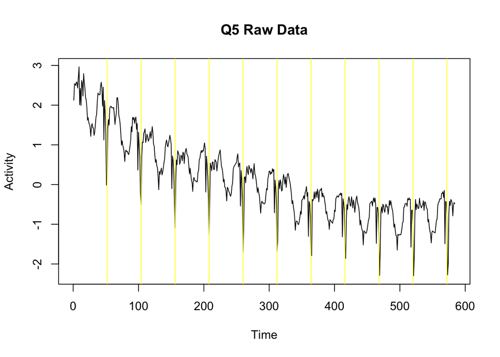

First we attempt to analyze a time series by plotting the original data to see if there is any possible structure. From the plot of this time series, we can see…

1. Seasonal feature: Same patterns seem to repeat every 52 data points. This can be interpreted as the data have a yearly seasonal trend (1 year = 52 weeks). Vertical lines(yellow) are added at multiples of 52.
2. Overall quadratic trend: There exists a general quadratic trend discernable by a slight parabolic shape.

We decided to use seasonal (with lag 52) and non-seasonal differencing method to address two observations.

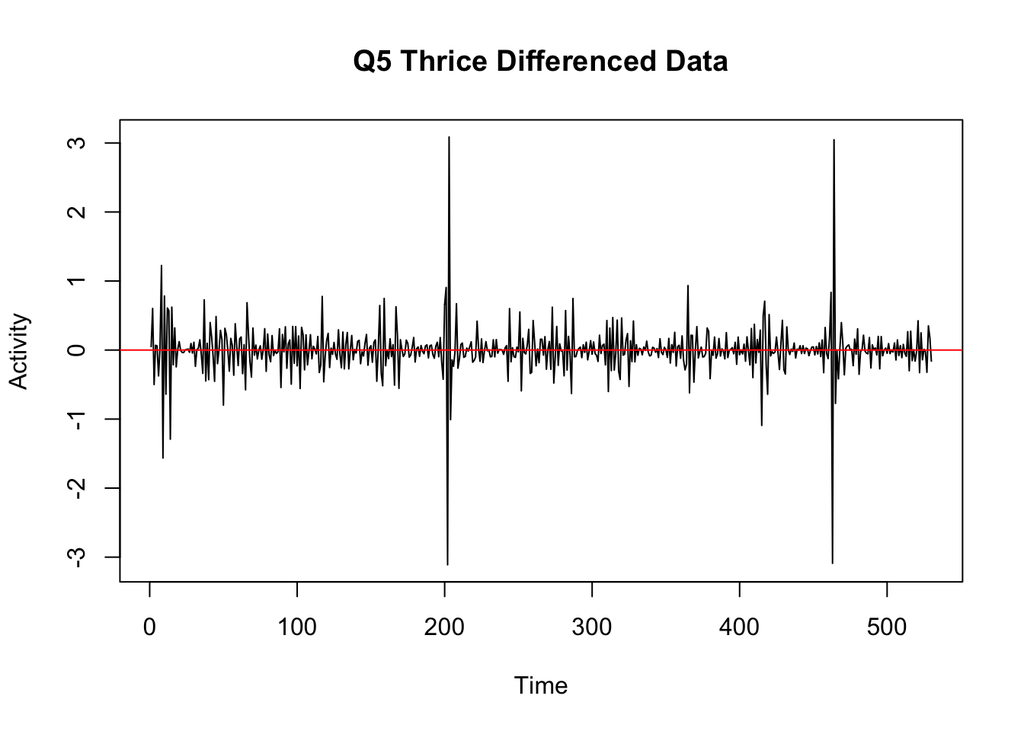

The differenced data looks stationary, showing mean zero feature. Thus, this differenced data can be used for further analysis. We examine the autocovariance and partial autocovariance plots of the differenced data for more insights.

# Examination of ACF & PACF of Differenced Data

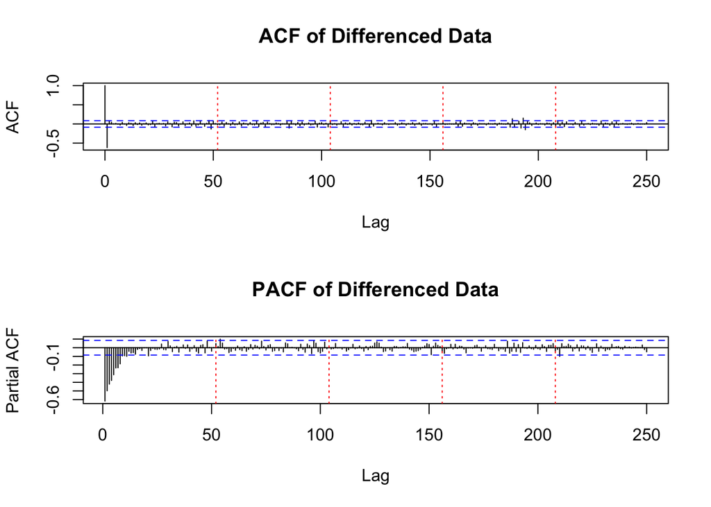

Two observations can be made: 1) Locally: acf has one significant spike at lag 1, while pacf tails off after few lags. 2) Seasonally: the structure does not seem complicated, as significant spikes only be observed at the period of 52 in both acf and pacf. However, the spike in pacf seems to be 1 lag off, which is plausible for a seasonal lag.

# Model Selection

With these observations, we start fitting simple seasonal ARIMA models. The local structure of acf and pacf suggests this may have MA(1) process component. For seasonal structure, significant spikes are observed only at the very first seasonal lag for both acf and pacf, we can eliminate AR(1) (no dying off structure in acf) and will start fitting with MA(1).

Thus we fit **$ARIMA(0, 2, 1) x (0, 1, 1)_{52}$** for the first attempt.

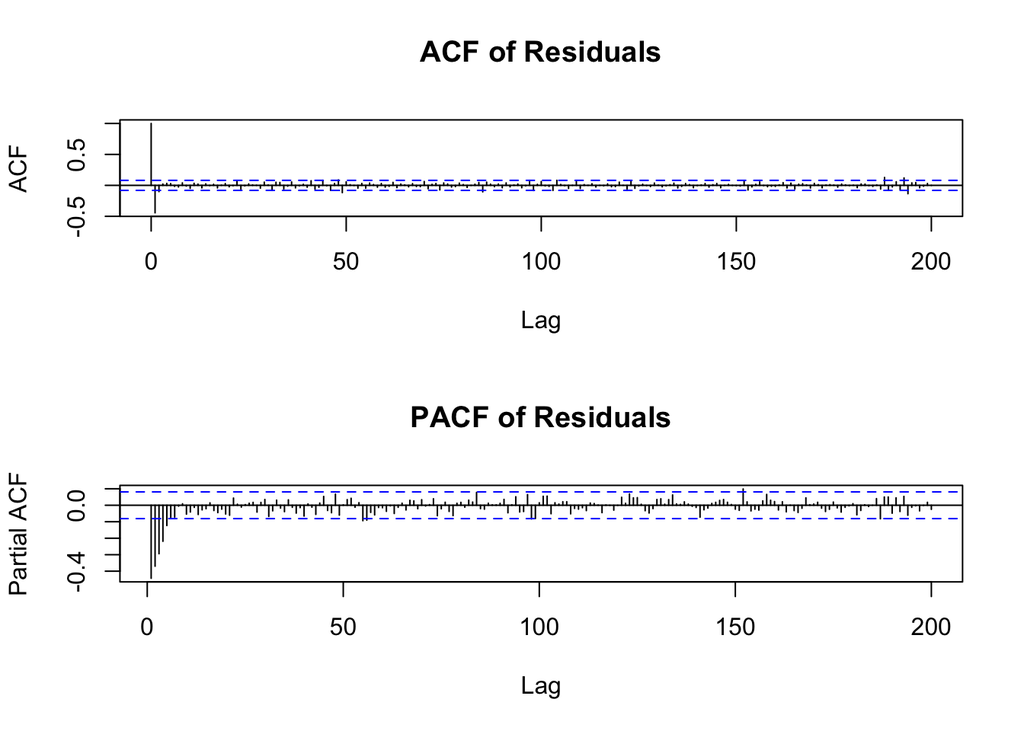

As can be seen in the above two plots, residuals from fitting $ARIMA(0, 2, 1) x (0, 1, 1)_{52}$ model still contains some structure, suggesting there may be a better model.

Thus we fix the seasonal part and try to fit different non-seasonal parameters. Based on the assessment of acf and pacf of the data and our first model, we will limit AR component up to 4, and MA component up to 2, and will apply all possible models within this range. In this analysis, we will use AIC and Cross-Validation to validate models.

Given limited amount of computational power, we’ll use a simple Cross-Validation algorithm. We assign the first 75% of known data to the training set, and the rest 25% to the test set. Fit models on the training set, then predict the test set with those models. Sum of Squared Errors (SSE) will be computed to specify the accuracy of the prediction, which will be compared across models, and a model with lowest SSE will be selected.

The following is the matrix of AIC statistics for potential models with the seasonal component fixed at (0,1,1).

```
##            MA(1)     MA(2)
## AR(0)  -47.32079 -327.5677
## AR(1) -161.61945 -325.5704
## AR(2) -239.94683 -331.4327
## AR(3) -289.51795 -331.7877
## AR(4) -316.15477 -329.8413
```

Repeating the above process, varying the seasonal component.

```
##            MA(1)     MA(2)
## AR(0)  -47.41765 -328.1112
## AR(1) -161.88021        NA
## AR(2) -240.02284 -331.9338
## AR(3) -289.92052 -332.3306
## AR(4) -316.58272        NA
```

```
##            MA(1)     MA(2)
## AR(0)  -50.67953 -326.7321
## AR(1) -164.18361        NA
## AR(2) -240.53999 -329.8520
## AR(3) -288.43121 -330.9436
## AR(4) -314.90415        NA
```

First, the following is the matrix of sum of squared errors (SSE) of potential models with the seasonal component fixed at (0,1,1).

```
##          MA(1)    MA(2)
## AR(0) 26.52649 27.06369
## AR(1) 25.68756 27.13967
## AR(2) 25.49337 26.69644
## AR(3) 25.54554 26.44179
## AR(4) 25.51665 26.02292
```

```
## [1] 38.85967
```

```
## [1] 33.23171
```

```
## [1] 43.7706
```

```
## [1] 34.95367
```

```
## [1] 30.21258
```

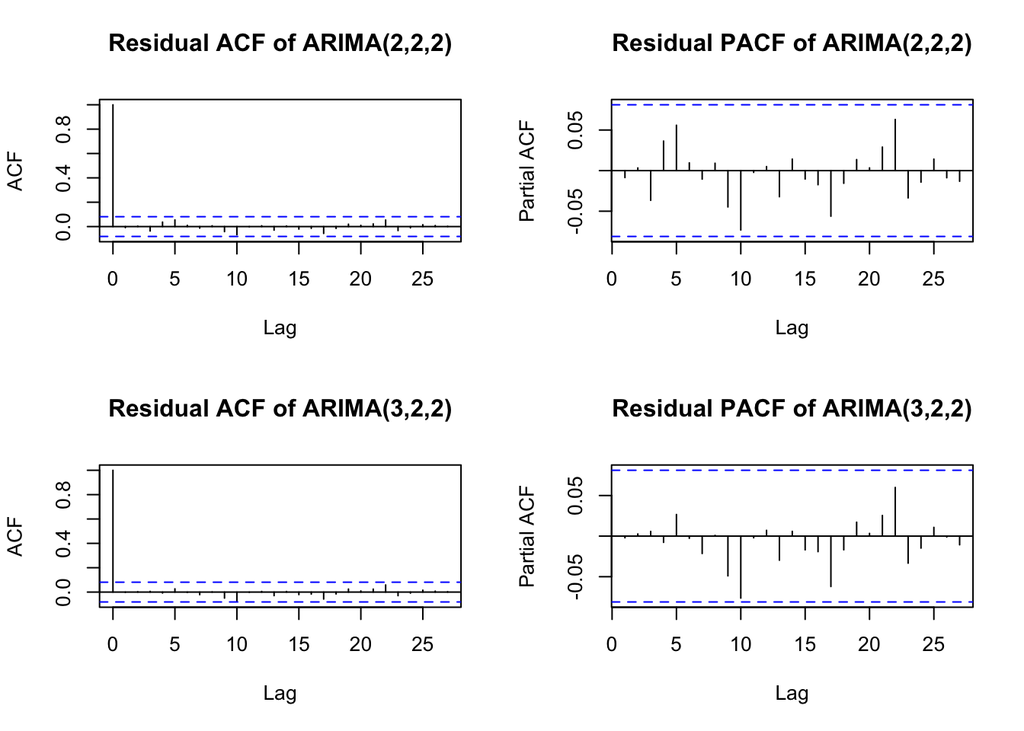

Thus our best model for Q5 will be **$ARIMA(2,2,2) x (0,1,1)_{52}$**. We will now use this model to predict the next 104 data points of this time series.

## Forecast

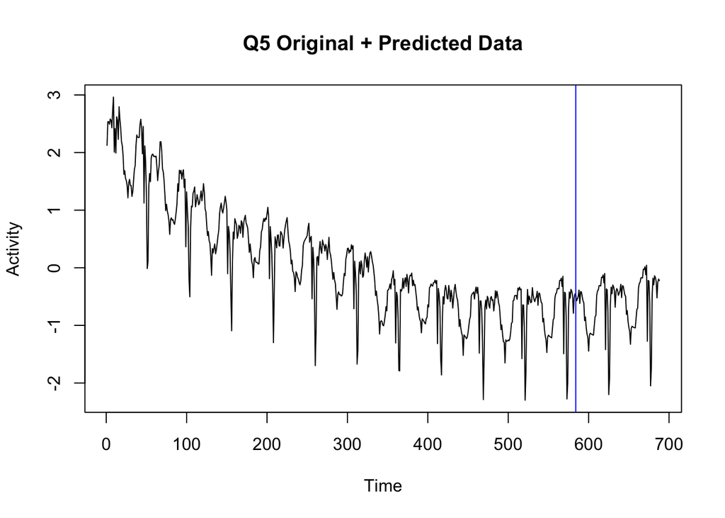

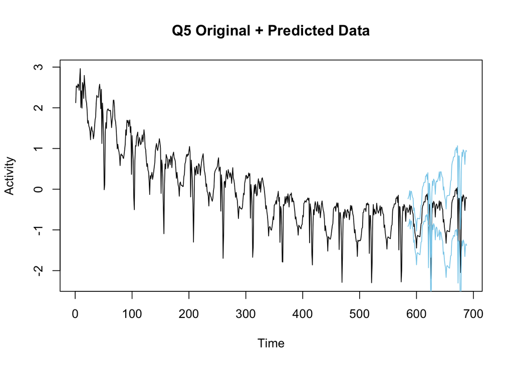

# Diagnostics

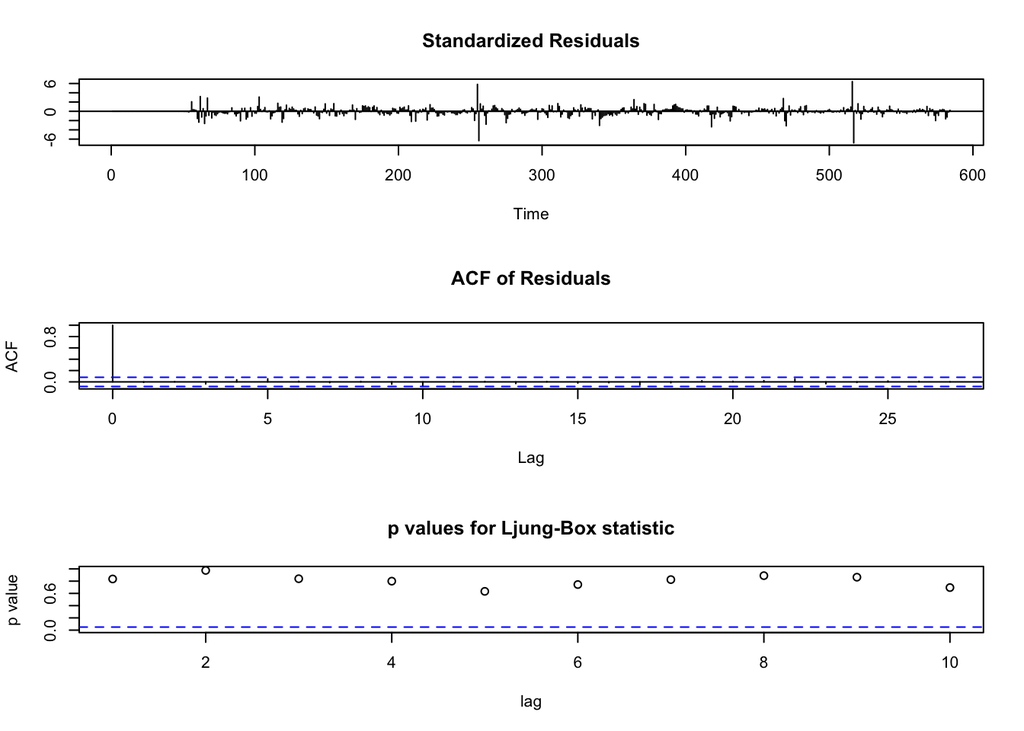

Figures above shows the residuals has mean zero and has no structure, which resemble behaviors of the white noise. Thus, our model is valid.

## Appendix

### R Code for the Report & Q5 Forecast

```r
q5 <- read.csv(file = "q5_train.csv", header = TRUE)

plot.ts(q5$activity, ylab = "Activity", main = "Q5 Original Data")
abline(v = 52 * (1:9), col = "blue")

q5_diff <- diff(diff(diff(q5$activity)), lag = 52)
plot.ts(q5_diff, ylab = "Activity", main = "Q5 Thrice Differenced Data")
abline(h = 0, col = "red")

par(mfrow = c(2,1))
acf(q5_diff, lag.max = 200, main = "ACF of Differenced Data")
abline(v = c(52,104,156), lty = 3, col = "red")
pacf(q5_diff, lag.max = 200, main = "PACF of Differenced Data")
abline(v = c(52,104,156), lty = 3, col = "red")

q5_fit_1st <- arima(q5$activity, order = c(0, 2, 1), seasonal =
                         list(order = c(0, 1, 1), period = 52), method = "CSS-ML")
par(mfrow = c(2,1))
acf(q5_fit_1st$residuals, lag.max = 200, main = "ACF of Residuals")
pacf(q5_fit_1st$residuals, lag.max = 200, main = "PACF of Residuals")

ReturnAIC <- function(data, p, d, q, P, D, Q){
  model <- as.list(tryCatch(arima(data, order = c(p,d,q), seasonal = list(order = c(P,D,Q), period = 52), method = "CSS-ML"), error = function(e){NA}
  ))
  if(is.na(model[1])){
    return(NA)
  }else{
    return(model$aic)
  }
}
AIC_Matrix <- function(data, ar, d, ma, P, D, Q){
  aic.matrix <- sapply(ma, function(q){
    sapply(ar, function(p){
      ReturnAIC(data,p,d,q,P,D,Q)
    })})
  colnames(aic.matrix) <- paste0("MA", "(", ma, ")")
  rownames(aic.matrix) <- paste0("AR", "(", ar, ")")
  return(aic.matrix)
}
AIC_Matrix_Seasonal <- function(data, p, d, q, AR, D, MA){
  aic.matrix <- sapply(MA, function(Q){
                  sapply(AR, function(P){
                    ReturnAIC(data,p,d,q,P,D,Q)
                })})
  colnames(aic.matrix) <- paste0("Seasonal MA", "(", MA, ")")
  rownames(aic.matrix) <- paste0("Seasonal AR", "(", AR, ")")
  return(aic.matrix)
}
case1 <- AIC_Matrix(data = q5$activity, 0:4,2,1:2,0,1,1)
case1

validation_SSE <- function(data,ar,d,ma,P,D,Q,mtd = "CSS-ML") {
  train_set <- data[1:438]
  test_set <- data[438:584]
  training_fit <- arima(train_set, order = c(ar,d,ma), seasonal = list(order = c(P,D,Q), period = 52), method = mtd)
  pred.set <- predict(training_fit, n.ahead = 132)$pred
  sse <- sum((pred.set - test_set) ^ 2)
  return(sse)
}
SSE_Matrix <- function(data, ar, d, ma, P, D, Q, mtd = "CSS-ML"){
  sse.matrix <- sapply(ma, function(ma){
                  sapply(ar, function(ar){
                    validation_SSE(data, ar, d, ma, P, D, Q, mtd = "CSS-ML")
                })})
  colnames(sse.matrix) <- paste("AR", "(", ma, ")" , sep='')
  rownames(sse.matrix) <- paste("AR", "(", ar, ")" , sep='')
  return(sse.matrix)
}
cross_validation_set_1 <- SSE_Matrix(data = q5$activity,0:4,2,1:2,0,1,1)
cross_validation_set_2 <- validation_SSE(q5$activity,1,2,2,1,1,0, mtd = "CSS")
cross_validation_set_3 <- validation_SSE(q5$activity,3,2,2,1,1,0, mtd = "CSS")
cross_validation_set_4 <- validation_SSE(q5$activity,0,2,2,1,1,1, mtd = "CSS")
cross_validation_set_5 <- validation_SSE(q5$activity,3,2,1,1,1,1, mtd = "CSS")
cross_validation_set_6 <- validation_SSE(q5$activity,4,2,1,1,1,1, mtd = "CSS")
cross_validation_set_1
cross_validation_set_2
cross_validation_set_3
cross_validation_set_4
cross_validation_set_5
cross_validation_set_6

q5_fit_2 <- arima(q5$activity, order = c(2, 2, 2), seasonal =
                         list(order = c(0, 1, 1), period = 52), method = "CSS-ML")
q5_fit_3 <- arima(q5$activity, order = c(3, 2, 2), seasonal =
                         list(order = c(0, 1, 1), period = 52), method = "CSS-ML")
par(mfrow = c(2,2))
acf(q5_fit_2$residuals, main = "Residual ACF of (2,2,2)")
pacf(q5_fit_2$residuals, main = "Residual PACF of ARIMA(2,2,2)")
acf(q5_fit_3$residuals, main = "Residual ACF of (3,2,2)")
pacf(q5_fit_3$residuals, main = "Residual PACF of (3,2,2)")

best.model <- q5_fit_2

par(mfrow = c(1,1))
q5.pred <- predict(best.model, n.ahead = 104)$pred
plot.ts(c(q5$activity, q5.pred), main = "Q5 Original + Predicted Data", ylab = "Activity")
abline(v = 575, col = "blue")

tsdiag(best.model)
write.table(q5.pred, "Q5_junz2703_23074461.txt", sep = ",", row.names = FALSE, col.names = FALSE)
```

## functions

```r
ReturnAIC <- function(data, p, d, q, P, D, Q){
  model <- as.list(tryCatch(arima(data, order = c(p,d,q), seasonal = list(order = c(P,D,Q), period = 52), method = "CSS-ML"), error = function(e){NA}
  ))
  if(is.na(model[1])){
    return(NA)
  }else{
    return(model$aic)
  }
}
AIC_Matrix <- function(data, ar, d, ma, P, D, Q){
  aic.matrix <- sapply(ma, function(q){
    sapply(ar, function(p){
      ReturnAIC(data,p,d,q,P,D,Q)
    })})
  colnames(aic.matrix) <- paste0("MA", "(", ma, ")")
  rownames(aic.matrix) <- paste0("AR", "(", ar, ")")
  return(aic.matrix)
}
AIC_Matrix_Seasonal <- function(data, p, d, q, AR, D, MA){
  aic.matrix <- sapply(MA, function(Q){
                  sapply(AR, function(P){
                    ReturnAIC(data,p,d,q,P,D,Q)
                })})
  colnames(aic.matrix) <- paste0("Seasonal MA", "(", MA, ")")
  rownames(aic.matrix) <- paste0("Seasonal AR", "(", AR, ")")
  return(aic.matrix)
}

validation_SSE <- function(data,ar,d,ma,P,D,Q,mtd = "CSS-ML") {
  train_set <- data[1:438]
  test_set <- data[438:584]
  training_fit <- arima(train_set, order = c(ar,d,ma), seasonal = list(order = c(P,D,Q), period = 52), method = mtd)
  pred.set <- predict(training_fit, n.ahead = 132)$pred
  sse <- sum((pred.set - test_set) ^ 2)
  return(sse)
}
SSE_Matrix <- function(data, ar, d, ma, P, D, Q, mtd = "CSS-ML"){
  sse.matrix <- sapply(ma, function(ma){
                  sapply(ar, function(ar){
                    validation_SSE(data, ar, d, ma, P, D, Q, mtd = "CSS-ML")
                })})
  colnames(sse.matrix) <- paste("AR", "(", ma, ")" , sep='')
  rownames(sse.matrix) <- paste("AR", "(", ar, ")" , sep='')
  return(sse.matrix)
}
```

### R Code for Q1 Forecast

```r
setwd("/Users/hyung/documents/R/Data/Class/Stat153/MT2")
q1 <- read.csv(file = "q1_train.csv", header = TRUE)
plot.ts(q1$activity, xlab = "Time in Weeks", ylab = "Activity", main = "Q1 Time Series")

min(q1$activity)
q1$logactivity <- log(q1$activity + 2.5)
plot.ts(q1$logactivity, xlab = "Weekly Time", ylab = "Log Activity", main = "Log Transformed Q1 Data")

diff.q1 <- diff(diff(q1$logactivity, lag = 52))
plot(diff.q1, xlab = "Weekly Time", ylab = "Log Activity",
     main = "Twice Differenced Log Transformed Q1 Data", type = "l")
abline(h=0, col = "red")
mean(diff.q1)

acf(diff.q1, lag.max = 320)
acf(diff.q1, lag.max = 20)
abline(v = c(52,104,156,208), col = "red", lty = 2)
pacf(diff.q1, lag.max = 320)
pacf(diff.q1, lag.max = 20)
abline(v = c(52,104,156,208), col = "red", lty = 2)

#seasonal(3,1,3)?
#local(0,1,1)?
#ARMA (1, 1, 0) x (P, 1, Q)
#ARMA (0, 1, 1) x (P, 1, Q)
#ARMA (1, 1, 1) x (P, 1, Q)
#ARMA (2, 1, 1) x (P, 1, Q)

AR <- c(0:3)
MA <- c(0:3)
case1 <- AIC_Matrix_Seasonal(q1$logactivity, 0,1,1,AR,1,MA)
case2 <- AIC_Matrix_Seasonal(q1$logactivity, 1,1,0,AR,1,MA)
case3 <- AIC_Matrix_Seasonal(q1$logactivity, 1,1,1,AR,1,MA)
case4 <- AIC_Matrix_Seasonal(q1$logactivity, 2,1,1,AR,1,MA)

#(0,1,1)x(2,1,3)(52) seem best

q1_fit <- arima(q1$logactivity, order = c(0,1,1),
                   seasonal = list(order = c(2,1,3), period = 52), method = "CSS-ML")

q1.pred_pred <- predict(q1_fit, n.ahead = 104)$pred

q1.pred_lwr<- predict(q1_fit, n.ahead = 104)$pred -
            predict(q1_fit, n.ahead = 104, interval = 'confidence')$se*1.96
q1.pred_upr<- predict(q1_fit, n.ahead = 104)$pred +
            predict(q1_fit, n.ahead = 104, interval = 'confidence')$se*1.96
q1.pred <- data.frame(exp(q1.pred_lwr)-2.5, exp(q1.pred_pred)-2.5, exp(q1.pred_upr)-2.5)


plot(forecast(arima.fit))

fcast.original <- exp(fcast$pred)-2.5
t <- c(1:(length(q1$activity)+104))
plot(t,c(q1$activity,q1.pred_pred), type = "l")
abline(v=526, col = "red")

write.table(q1.pred, "Q1_junz2703_23074461.txt", sep = ",", row.names = FALSE, col.names = FALSE)
```

### R Code for Q2 Prediction

```r
q2 <- read.csv(file = "q2_train.csv", header = TRUE)

plot.ts(q2$activity)
abline(v=52*(1:9))
q2_diff <- diff(diff(diff(q2$activity, lag = 52)))
plot.ts(q2_diff)
acf(q2_diff, lag.max = 200)
abline(v=52*(1:3), lty = 3, col = "red")
pacf(q2_diff, lag.max = 200)
abline(v=52*(1:3), lty = 3, col = "red")

AIC_Matrix(data = q2$activity,0:4,2,1:2,0,1,1)
SSE_Matrix(data = q2$activity,0:4,2,1:2,0,1,1)

q2_fit_1 <- arima(q2$activity, order = c(1, 2, 2), seasonal =
                    list(order = c(0, 1, 1), period = 52), method = "CSS-ML")
acf(q2_fit_1$residuals, lag.max = 200)
pacf(q2_fit_1$residuals, lag.max = 200)

q2.pred_pred <- predict(q2_fit_1, n.ahead = 104)$pred
q2.pred_lwr<- predict(q2_fit_1, n.ahead = 104)$pred -
            predict(q2_fit_1, n.ahead = 104, interval = 'confidence')$se*1.96
q2.pred_upr<- predict(q2_fit_1, n.ahead = 104)$pred +
            predict(q2_fit_1, n.ahead = 104, interval = 'confidence')$se*1.96
q2.pred <- data.frame(q2.pred_lwr, q2.pred_pred, q2.pred_upr)


plot.ts(c(q2$activity, q2.pred), main = "q2 Original + Predicted Data", ylab = "activity")
abline(v = 575, lty = 3, col = "red")

write.table(q2.pred, "Q2_junz2703_23074461.txt", sep = ",", row.names = FALSE, col.names = FALSE)
```

### R Code for Q3 Forecast

```r
setwd("/Users/hyung/documents/R/Data/Class/Stat153/MT2")
q3 <- read.csv(file = "q3_train.csv", header = TRUE)
plot.ts(q3$activity)
abline(v=52*(1:9))
q3_diff <- diff(diff(diff(q3$activity, lag = 52)))
plot.ts(q3_diff)
acf(q3_diff, lag.max = 200)
abline(v=52*(1:3), lty = 3, col = "red")
pacf(q3_diff, lag.max = 200)
abline(v=52*(1:3), lty = 3, col = "red")
AIC_Matrix(data = q3$activity,0:4,2,1:2,0,1,1)
SSE_Matrix(data = q3$activity,0:4,2,1:2,0,1,1)
q3_fit_1 <- arima(q3$activity, order = c(1, 2, 2), seasonal =
                    list(order = c(0, 1, 1), period = 52), method = "CSS-ML")
acf(q3_fit_1$residuals, lag.max = 200)
pacf(q3_fit_1$residuals, lag.max = 200)

q3_fit_2 <- arima(q3$activity, order = c(1, 2, 2), seasonal =
                    list(order = c(1, 1, 1), period = 52), method = "CSS")

validation_SSE(data = q3$activity,1,2,2,1,1,1,mtd = "CSS")

q3_fit_1 <- arima(q3$activity, order = c(1, 2, 2), seasonal =
                    list(order = c(0, 1, 1), period = 52), method = "CSS-ML")
q3.pred <- predict(q3_fit_1, n.ahead = 104)$pred
q3.pred_pred <- predict(q3_fit_1, n.ahead = 104)$pred
q3.pred_lwr<- predict(q3_fit_1, n.ahead = 104)$pred -
            predict(q3_fit_1, n.ahead = 104, interval = 'confidence')$se*1.96
q3.pred_upr<- predict(q3_fit_1, n.ahead = 104)$pred +
            predict(q3_fit_1, n.ahead = 104, interval = 'confidence')$se*1.96
q3.pred <- data.frame(q3.pred_lwr, q3.pred_pred, q3.pred_upr)


plot.ts(c(q3$activity, q3.pred), main = "q3 Original + Predicted Data", ylab = "activity")
abline(v = 525, lty = 3, col = "red")

write.table(q3.pred, "Q3_junz2703_23074461.txt", sep = ",", row.names = FALSE, col.names = FALSE)
```

### R Code for Q4 Prediction

```r
setwd("/Users/hyung/documents/R/Data/Class/Stat153/MT2")
q4 <- read.csv(file = "q4_train.csv", header = TRUE)

library("forecast")
plot.ts(q4$activity, xlab = "Time in Weeks", ylab = "Activity", main = "Q4 Time Series")

diff.q4 <- diff(q4$activity)
plot(diff.q4, xlab = "Weekly Time", ylab = "Activity",
     main = "Differenced Q4 Data", type = "l")
abline(h=0, col = "red")
mean(diff.q4)

acf(diff.q4, lag.max = 320)
acf(diff.q4, lag.max = 20)
pacf(diff.q4, lag.max = 320)
pacf(diff.q4, lag.max = 20)

#Seems like ARIMA(2,1,1) with no seasonal component
ar <- c(0:3)
ma <- c(0:3)
q4_case1 <- AIC_Matrix(q4$activity,ar,1,ma,0,0,0)
q4_case2 <- AIC_Matrix(q4$activity,ar,1,ma,1,0,0)
q4_case3 <- AIC_Matrix(q4$activity,ar,1,ma,2,0,0)
q4_case4 <- AIC_Matrix(q4$activity,ar,1,ma,1,0,1)

q4_case1
q4_case2
q4_case3
q4_case4
#Seems like seasonal(1,0,0) may be the correct seasonal portion
q4.validation <- SSE_Matrix(q4$activity,ar,1,ma,1,0,0, mtd = "CSS")
q4.validation
#ARMA(1,1) seems the most reasonable
#Try other possibilities
validation_SSE(q4$activity,1,1,1,0,0,0, mtd = "CSS")
validation_SSE(q4$activity,3,1,1,0,0,0, mtd = "CSS")
validation_SSE(q4$activity,1,1,1,2,0,0, mtd = "CSS")
validation_SSE(q4$activity,3,1,1,1,0,1, mtd = "CSS")
#(1,1,1)x(1,0,0)(52) has the lowest SSE
q4_fit <- arima(q4$activity, order = c(1, 1, 1), seasonal =
                    list(order = c(1, 0, 0), period = 52), method = "CSS")

q4_fit <- arima(q4$activity, order = c(1,1,1), seasonal = list(order = c(1,0,0),
                     period = 52, method = "CSS"))

q4.pred <- predict(q4_fit, n.ahead = 104)$pred
q4.pred_pred <- predict(q4_fit, n.ahead = 104)$pred
q4.pred_lwr<- predict(q4_fit, n.ahead = 104)$pred -
            predict(q4_fit, n.ahead = 104, interval = 'confidence')$se*1.96
q4.pred_upr<- predict(q4_fit, n.ahead = 104)$pred +
            predict(q4_fit, n.ahead = 104, interval = 'confidence')$se*1.96
q4.pred <- data.frame(q4.pred_lwr, q4.pred_pred, q4.pred_upr)
t <- c(1:(length(q4$activity)+104))
plot(t,c(q4$activity,q4.pred$q4.pred_pred), type = "l")
abline(v=526, col = "red")

write.table(q4.pred, "Q4_junz2703_23074461.txt", sep = ",", row.names = FALSE, col.names = FALSE)
```